# Support Vector Machines

ref:

- http://www.tristanfletcher.co.uk/SVM%20Explained.pdf
- cran.r-project.org/web/packages/e1071/vignettes/svmdoc.pdf
- http://videolectures.net/epsrcws08_campbell_isvm/ [video]

## Introduction

Consider a binary classification, where input vectors \( x_i \) (the input space) and labels (aka, targets, classes) \( y_i = \pm 1 \).

```r
x1s <- c(.5,1,1,2,3,3.5,     1,3.5,4,5,5.5,6)
x2s <- c(3.5,1,2.5,2,1,1.2,  5.8,3,4,5,4,1)
ys <- c(rep(+1,6),          rep(-1,6))
my.data <- data.frame(x1=x1s, x2=x2s, type=as.factor(ys))
my.data
```

```
    x1  x2 type
1  0.5 3.5    1
2  1.0 1.0    1
3  1.0 2.5    1
4  2.0 2.0    1
5  3.0 1.0    1
6  3.5 1.2    1
7  1.0 5.8   -1
8  3.5 3.0   -1
9  4.0 4.0   -1
10 5.0 5.0   -1
11 5.5 4.0   -1
12 6.0 1.0   -1
```

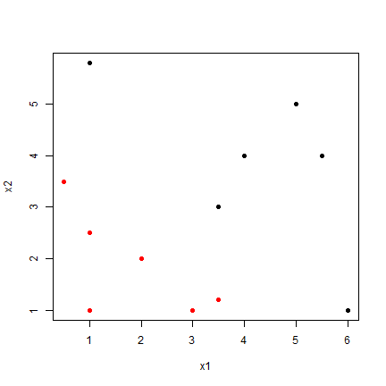

```r
plot(my.data[,-3],col=(ys+3)/2, pch=19); abline(h=0,v=0,lty=3)
```

In SVM the error is minimized by maximizing the *margin* \( \gamma \), ie., the minimal distance between the hyperplane separating the two classes and the closest datapoints of each class (called *support vectors*).

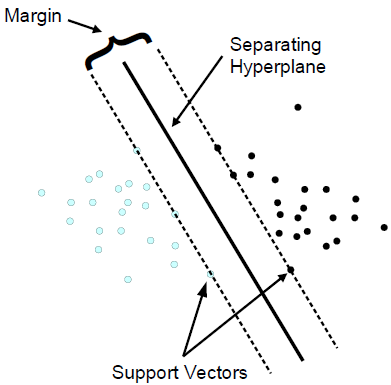

The separating hyperplane can be written as \[ w.x + b = 0 \] where vector b is the bias, and w the weigths.

w is the normal to the hyperplane and \( \frac{b}{\|w\|} \) is the perpendicular distance from the hyperplane to the origin

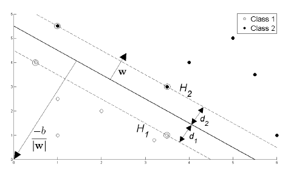

Deciding the class for a new observation \( x_i \) is calculated by \[ D(x_i) = signal(w.x_i + b) \]

\( D() \) is invariant under a positive scaling \( w \rightarrow \lambda w \), \( b \rightarrow \lambda b \). We fix \( \lambda \) such that the *margin* has distance \( 1 \), and so \[ w.x + b = 1 \] or \[ w.x + b = -1 \] for the support vectors of one or the other side. This defines what is called by *canonical hyperplane*.

If \( x_1, x_2 \) are support vectors of each side, then subtracting the previous equations: \[ w.(x_1 - x_2) = 2 \]

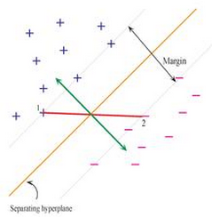

If we project the vector \( x_1 - x_2 \) (the red vector above) onto the normal to the hyperplane, ie, \( \frac{w}{\|w\|} \), we get twice the size of the margin:

\[ (x_1 - x_2) . \frac{w}{\|w\|} = \frac{w.(x_1 - x_2)}{\|w\|} = \frac{2}{\|w\|} \]

So \( \gamma = \frac{1}{\|w\|} \).

We want to maximize the margin \( \gamma \). So we need to maximize \( \frac{1}{\|w\|} \), ie, minimize \( \|w\| \) which is the same as minimize \( \frac{1}{2}\|w\|^2 \).

But this minimization has constraints. The vector \( w \) must be such that all following conditions remain true \[ y_i (w.x_i + b) \geq 1 \] which respects the classification of the original dataset. The equations only return 1 for the support vectors. For every other datapoint, the value will be greater than one.

*This optimization requires Langrage multipliers which we will not follow (check the references above)*

This optimization will provide us with values \( \alpha_i \) such that: \[ w = \sum_i \alpha_i y_i x_i \] \[ \sum_i \alpha_i y_i = 0 \]

where if \( x_i \) is a support vector then \( \alpha_i>0 \) (or zero otherwise).

and being \( S \) the indexes of the support vectors: \[ b = \frac{1}{|S|} \sum_{s \in S} \Big( y_s - x_s . \sum_{m \in S} \alpha_m y_m x_m \Big) \]

with \( b \) and \( w \) the hyperplane is defined and we get our SVM!

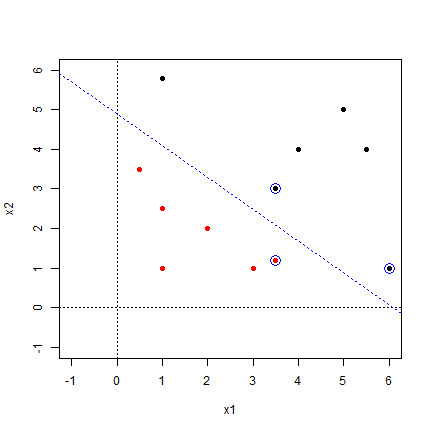

```r
library(e1071)
svm.model <- svm(type ~ ., data=my.data, type='C-classification', kernel='linear',scale=FALSE)

plot(my.data[,-3],col=(ys+3)/2, pch=19, xlim=c(-1,6), ylim=c(-1,6)); abline(h=0,v=0,lty=3)
points(my.data[svm.model$index,c(1,2)],col="blue",cex=2) # show the support vectors

# get parameters of hiperplane
w <- t(svm.model$coefs) %*% svm.model$SV
b <- -svm.model$rho
# in this 2D case the hyperplane is the line w[1,1]*x1 + w[1,2]*x2 + b = 0
abline(a=-b/w[1,2], b=-w[1,1]/w[1,2], col="blue", lty=3)
```

And let's make a prediction:

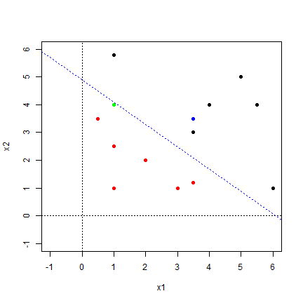

```r
observations <- data.frame(x1=c(1,3.5),x2=c(4,3.5))

plot(my.data[,-3],col=(ys+3)/2, pch=19, xlim=c(-1,6), ylim=c(-1,6)); abline(h=0,v=0,lty=3)
points(observations[1,], col="green", pch=19)
points(observations[2,], col="blue", pch=19)
abline(a=-b/w[1,2], b=-w[1,1]/w[1,2], col="blue", lty=3)
```

```r
predict(svm.model, observations) # the results are right
```

```
 1  2
 1 -1
Levels: -1 1
```

Another eg with the iris dataset:

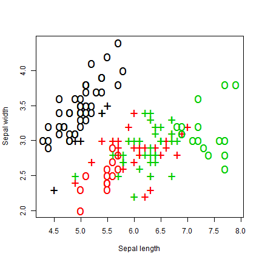

```r
data(iris)
svm.model <- svm(Species ~ Sepal.Length + Sepal.Width, data = iris, kernel = "linear")
# the + are support vectors
plot(iris$Sepal.Length, iris$Sepal.Width, col = as.integer(iris[, 5]),
     pch = c("o","+")[1:150 %in% svm.model$index + 1], cex = 2,
     xlab = "Sepal length", ylab = "Sepal width")
```

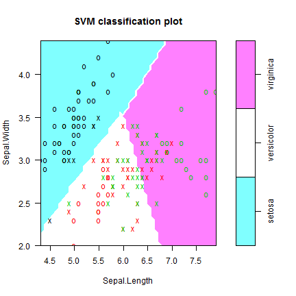

```r
plot(svm.model, iris, Sepal.Width ~ Sepal.Length,
     slice = list(sepal.width = 1, sepal.length = 2))
```

```r
svm.pred  <- predict(svm.model, iris[,-5])
table(pred = svm.pred, true = iris[,5]) # show the confusion matrix
```

```
            true
pred         setosa versicolor virginica
  setosa         49          0         0
  versicolor      1         38        15
  virginica       0         12        35
```

TODO: experimentar fazer um eg 3d? http://stackoverflow.com/questions/8017427/plotting-data-from-an-svm-fit-hyperplane

## Non linearly separable data

Notice that \( x_i \) always appear in a dot product. This means that the results do not depend in the input space's dimension. So, one way is to increase the dimension of the data using a mapping \( \phi \), turning each \( x_i \) into \( \phi(x_i) \), such that the new data may be linearly separable: \[ x_i . x_j \rightarrow \phi(x_i) . \phi(x_j) \]

Here's an eg how to separate the 2D blue cloud using height in 3D:

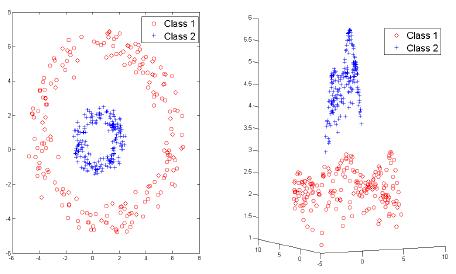

This higher dimensional space is called a *feature space* and it must be a *Hilbert space* (ie, the concept of dot product applies).

The function \[ K(x_i,x_j) = \phi(x_i) . \phi(x_j) \] is called a *kernel* (in fact we just need to know the kernel, not the mapping \( \phi \)). The kernel is, therefore, the inner product between mapped pairs of points in feature space.

Different choices of kernel define different Hilbert spaces to use.

Some popular kernels:

- Linear kernel (the one use implicitly) \[ K(x_1,x_2) = x_1^T.x_2 \]
- RBF kernels \[ K(x_1,x_2) = exp(\frac{-\|x_1-x_2\|^2}{2\sigma^2}) \]
- Polynomial kernels \[ K(x_1,x_2) = ( x_1.x_2 + a)^b \]
- Sigmoidal kernels \[ K(x_1,x_2) = tanh(a x_1.x_2 - b) \]

where \( a,b \) are parameters defining the kermel's behaviour.

Kernels can also be defined by algorithms, not only by functions.

The decision function becomes \[ D(z) = sign\big(\sum_i \alpha_i y_i K(x_i,z) + b\big) \]

An R eg using the polynomial kernel \( (0.1 x_1.x_2 + 1)^8 \):

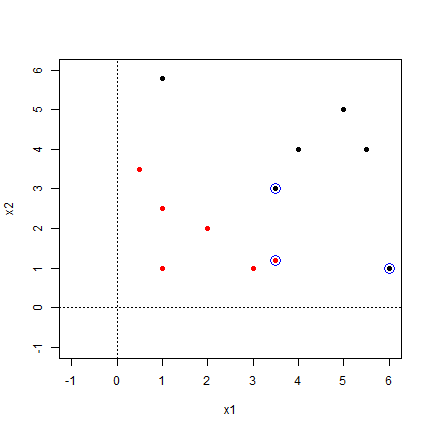

```r
svm.model <- svm(type ~ ., data=my.data, type='C-classification', kernel='polynomial', degree=8, gamma=0.1, coef0=1, scale=FALSE)

plot(my.data[,-3],col=(ys+3)/2, pch=19, xlim=c(-1,6), ylim=c(-1,6)); abline(h=0,v=0,lty=3)
points(my.data[svm.model$index,c(1,2)],col="blue",cex=2) # show the support vectors
```

```r
svm.pred <- predict(svm.model, my.data[,-3])
table(pred = svm.pred, true = my.data[,3])
```

```
    true
pred -1 1
  -1  6 0
  1   0 6
```

Using the same kernel with the iris dataset:

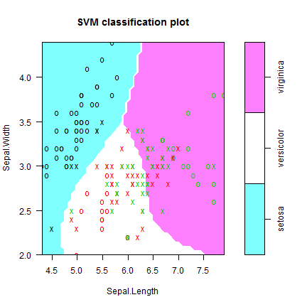

```r
svm.model <- svm(Species ~ Sepal.Length + Sepal.Width, data = iris, kernel = 'polynomial', degree=8, gamma=0.1, coef0=1)
plot(svm.model, iris, Sepal.Width ~ Sepal.Length,
     slice = list(Sepal.Width = 1, Sepal.Length = 2))
```

```r
svm.pred  <- predict(svm.model, iris[,-5])
table(pred = svm.pred, true = iris[,5]) # show the confusion matrix
```

```
            true
pred         setosa versicolor virginica
  setosa         50          0         0
  versicolor      0         37        15
  virginica       0         13        35
```

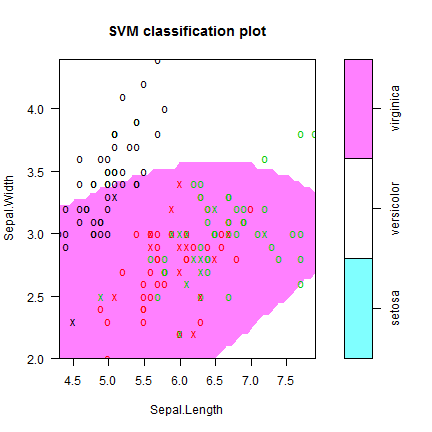

```r
# not very great, but we had just used two attributes. If we use all four:
svm.model <- svm(Species ~ ., data = iris, kernel = 'polynomial', degree=8, gamma=0.1, coef0=1)
plot(svm.model, iris, Sepal.Width ~ Sepal.Length,
     slice = list(Petal.Width = 3, Petal.Length = 2.5)) # showing a 2D slice of the 4D space
```

```r
svm.pred  <- predict(svm.model, iris[,-5])
table(pred = svm.pred, true = iris[,5]) # show the confusion matrix
```

```
            true
pred         setosa versicolor virginica
  setosa         50          0         0
  versicolor      0         48         1
  virginica       0          2        49
```

## Soft Margins

The constraints that SVM must abide \[ w.x_i + b \geq 1, y_i = +1 \] \[ w.x_i + b \leq -1, y_i = -1 \] may be too strict to handle data not fully linearly separable (perhaps because of noise or outliers)

One way is to relax these constraints: \[ w.x_i + b \geq 1 - \xi_i, y_i = +1 \] \[ w.x_i + b \leq -1 + \xi_i, y_i = -1 \] with \( \forall_i \xi_i \geq 0 \)

creating what is called *soft margins*.

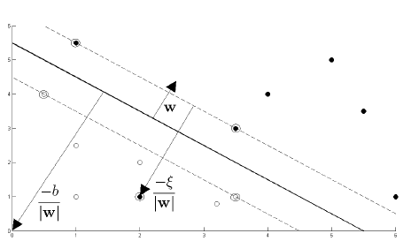

In this soft margin SVM, data points on the incorrect side of the margin boundary have a penalty that increases with the distance from it. As we are trying to reduce the number of misclassications, a sensible way to adapt our objective function \( \frac{1}{2}\|w\|^2 \), is to minimize: \[ \frac{1}{2}\|w\|^2 + C \sum_i \xi_i \] obyeing the relaxed restrictions, where \( C \) controls the trade-of between the slack variable penalty and the size of the margin. A value \( C \) much larger than \( 0 \) converges to the original SVM algorithm. Unfortunately the optimal value of \( C \) must come from trial-and-error.

This is again an optimization procedure that falls out the scope of this tutorial.

Let's test it with a wicked dataset:

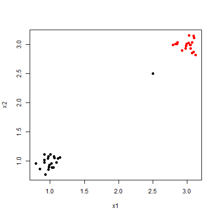

```r
set.seed(101)
x1s <- c( rnorm(20,1,0.1), 2.5, rnorm(20,3,0.1))
x2s <- c( rnorm(20,1,0.1), 2.5, rnorm(20,3,0.1))
ys  <- c( rep(-1,21), rep(1,20))
my.data <- data.frame(x1=x1s, x2=x2s, type=as.factor(ys))
plot(my.data[,-3],col=(ys+3)/2, pch=19)
```

First with a hard-core margin (use option `cost`):

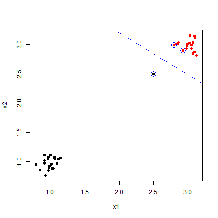

```r
svm.model <- svm(type ~ ., data=my.data, type='C-classification', kernel='linear', cost=1e10, scale=FALSE)

plot(my.data[,-3],col=(ys+3)/2, pch=19)
points(my.data[svm.model$index,c(1,2)],col="blue",cex=2) # show the support vectors

# get parameters of hiperplane
w <- t(svm.model$coefs) %*% svm.model$SV
b <- -svm.model$rho
# in this 2D case the hyperplane is the line w[1,1]*x1 + w[1,2]*x2 + b = 0
abline(a=-b/w[1,2], b=-w[1,1]/w[1,2], col="blue", lty=3)
```

Now a soft-margin:

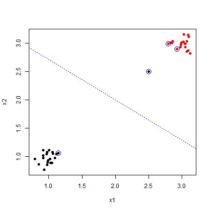

```r
svm.model <- svm(type ~ ., data=my.data, type='C-classification', kernel='linear', cost=1, scale=FALSE)

plot(my.data[,-3],col=(ys+3)/2, pch=19)
points(my.data[svm.model$index,c(1,2)],col="blue",cex=2) # show the support vectors

# get parameters of hiperplane
w <- t(svm.model$coefs) %*% svm.model$SV
b <- -svm.model$rho
# in this 2D case the hyperplane is the line w[1,1]*x1 + w[1,2]*x2 + b = 0
abline(a=-b/w[1,2], b=-w[1,1]/w[1,2], col="blue", lty=3)
```

An important variant is when we consider one type of error more costly than the other (say, in a medical test for cancer, we prefer a false positive than a false negative, since in the later a sick patient will go untreated). To solve it, we assign different costs to each class: \[ \frac{1}{2}\|w\|^2 + C_+ \sum_{i_+} \xi_i + C_- \sum_{i_-} \xi_i \] where \( i_- \) are the indexes where \( y_i=-1 \), and \( i_+ \) for \( y_i=+1 \).

This is done at R's `svm()` with option `class.weights`

```r
# using the previous dataset...
costs <- table(my.data$type)  # the weight vector must be named with the classes names
costs[1] <- 1e10 # a class -1 mismatch has a terrible cost
costs[2] <- 1    # a class +1 mismatch not so much...
costs
```

```
   -1     1
1e+10 1e+00
```

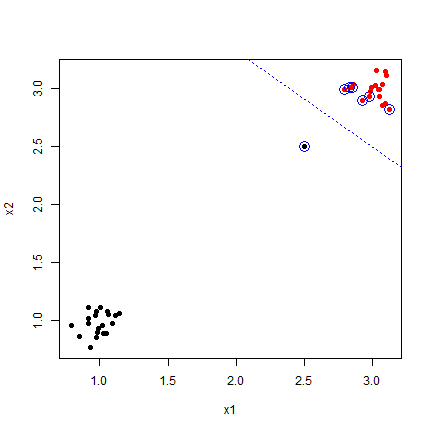

```r
svm.model <- svm(type ~ ., data=my.data, type='C-classification', kernel='linear', class.weights=costs, scale=FALSE)

plot(my.data[,-3],col=(ys+3)/2, pch=19)
points(my.data[svm.model$index,c(1,2)],col="blue",cex=2) # show the support

# get parameters of hiperplane
w <- t(svm.model$coefs) %*% svm.model$SV
b <- -svm.model$rho
# in this 2D case the hyperplane is the line w[1,1]*x1 + w[1,2]*x2 + b = 0
abline(a=-b/w[1,2], b=-w[1,1]/w[1,2], col="blue", lty=3)
```

We see that the algorithm, even with soft margins, decided to not take the risk of assigning a mismatch despite the probably outlier of class -1 (ie, the (2.5,2.5) data point).

## Multi-classes

If the dataset has a small number of classes, it's possible to reduce them into a set of binary classifications. Say we have three classes, \( 1,2,3 \), we can split the process into three binary classifications like the method shown in the next DAG:

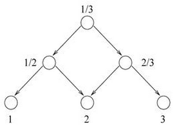

If the dataset has many classes, it's probably best to pick another method…

Anyway, to allow for multi-class classification, `svm()` uses the one-against-one technique by fitting all binary subclassifiers and finding the correct class by a voting mechanism. There are several classification variants, which can be specified in the `type` option (check `?svm` help file). This is done automatically.

## SVM for regression

In this task we are not trying to classify a new observation \( x_i \) into \( y_i \pm 1 \) but, instead, predict a real value for \( y \) such that for all \( x_i \) we have a real (not just binary) \( y_i \) such that \[ y_i = w.x_i + b \]

The algorith will output a \( y \) that minimizes some error function. However, it considers that for a given minimal distance \( \epsilon \) the error is still zero, so the regression line, in terms of the error function is more like a tube (called the *\( \epsilon \)-insensitive tube*):

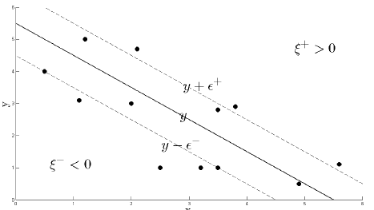

The regions outside the tube are given different penalties, if they lie 'above', \( \xi^+ \gt 0 \), or 'below', \( \xi^- \gt 0 \).

The error function for SVM regression is \[ \frac{1}{2}\|w\|^2 + C \sum_i (\xi^+_i + \xi^-_i) \]

which is again the subject of an optimization procedure that finds the optimal \( y \).

Function `svd()` uses option `type="eps-regression"`. An eg:

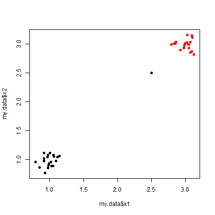

```r
# must transform type from factor to numeric, in order to perform regression
my.data$type <- (my.data$type == "1")*2 - 1
svm.model <- svm(type ~ ., data=my.data, type="eps-regression")
predict.y <- predict(svm.model, my.data[,-3])
plot(my.data$x1, my.data$x2, pch=19, col=round(predict.y+3)/2) # perfect
```

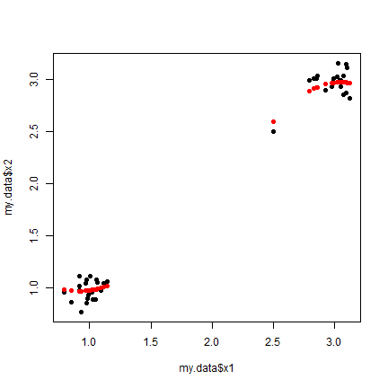

```r
# we can also predict one attribute based on another
svm.model <- svm(my.data$x1, my.data$x2, type="eps-regression")
predict.x2 <- predict(svm.model, my.data$x1)
plot(my.data$x1, my.data$x2, pch=19)
points(my.data$x1, predict.x2, pch=19, col="red")
```